# MATH-156 - Week 8 - Confidence Intervals for One Proportion

**Directions**:

- For this activity, I’d like you record your responses in a word doc or a shared google doc
  - If you need to re-download the data-explorer app, you can find it here: https://remiller1450.github.io/m156f20/app_setup.html
- On certain questions you will be asked to include screenshots
  - On Windows PCs, you can use the snipping tool app (start typing “snipping tool” into the Windows search bar)
  - On Mac PCs, there are several ways to take a screenshot: https://www.cleverfiles.com/howto/snipping-tool-mac.html
- On Canvas you may submit either your answer document itself, or a link to the google doc (make sure I have permission to view it)
  - Your score will be mostly based upon effort, and it’s okay if you don’t finish. But recognize that these questions are excellent practice for the upcoming exam.

## Introduction

The video lectures for this week introduced the concept of **interval estimation**, or using a range of plausible to estimate a characteristic of a population. In general, interval estimates have the form:
$$\text{Point Estimate} \pm \text{Margin of Error}$$

- If our sampling method is *unbiased*, coming up with a point estimate is easy
- The question we will try to answer is how can we determine a *statistically meaningful* margin of error?

**Question #0**: Record how many of your intervals were correct in the trivia activity. What does this tell you about the margins of error that you used?

$~$

### Coin flips

In this section we’ll consider a very simple random process, flipping a fair coin 30 times. Recognize that until we actually do the coin flips, we cannot know the proportion of “heads” in our sample. The **sampling distribution** will describe the distribution of possible sample proportions that we might expect to see. Studying the sampling distribution will provide us a starting point in determining a *meaningful margin of error* to use when coming up with an interval estimate.

**Question #1**: How many different *sample proportions* (of “heads”) could possibly be observed in a sample of $n = 30$ coin flips?

**Question #2**: Use [this StatKey page](https://www.lock5stat.com/StatKey/sampling_1_cat/sampling_1_cat.html) to repeat this random process 2,000 different times. Be sure you change the proportion (“Edit Proportion”) and sample size ($n = \_$) to reflect this scenario (30 coin-flips). Report the *center* (mean), *spread* (std. error), and *shape* of the sampling distribution in your write-up.

$~$

### Central Limit Theorem

The video lectures for this week introduced a theoretical result known as Central Limit theorem (CLT) that described the distribution of sample averages (remember that a proportion is just an average of 0’s and 1’s). We used Central Limit theorem to suggest the following model for the *sampling distribution* of a single proportion:
$$\hat{p} \sim N\bigg(p, \sqrt{\tfrac{p(1-p)}{n}}\bigg)$$

**Question #3**: In our own words, write one sentence summarizing the statistical notation above (ie: $\hat{p} \sim \ldots$)

**Question #4**: How does the *theoretical* sampling distribution suggested by CLT compare to the *simulated* sampling distribution you found in Question #2? Compare the *center*, *spread*, and *shape* of each.

$~$

### From Sampling Distributions to Confidence Intervals

A $P\%$ confidence interval is an interval estimate found *using a procedure* with a $P\%$ long-run success rate. This means that an individual sample might produce a confidence interval that will “miss” the population characteristic, but if the same procedure were applied to many different random samples it would succeed $P\%$ of the time. The key to having a certain long-run success rate is the *margin of error*. If the margin of error is too large, the confidence interval will be more successful than advertised, while if the margin of error is too small, the confidence interval will be less successful than advertised.

**Question #5**: Based upon the definition given above, if you were given 100 different 95% confidence interval estimates, how many would you expect to actually contain the population characteristic of interest?

$~$

A sensible method for coming up with a margin of error that’s “just right” is to use the *sampling distribution* to find a number to add and subtract from the point estimate that would results in an interval covering $P\%$ of the possible sample proportions. Based upon the sampling distribution below, it looks like adding/subtracting 0.17 (approximately) would do the trick:

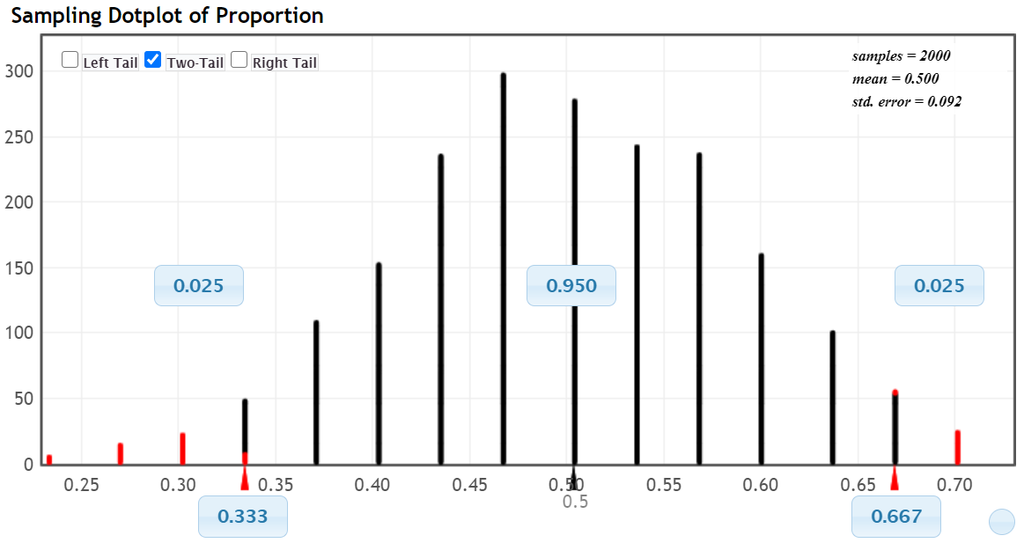

In any real application, we don’t have the luxury of being able to repeated sample our population. But this is where Central Limit theorem helps us out, we can estimate the *variability* in the sampling distribution from just a single sample. All we need to do is estimate $p$ and apply what we know about the Normal distribution. The next two questions will walk through this process.

**Question #6**: Click “Reset plot” to clear all of the previous samples you’d collected. Then hit “Generate 1 Sample” and notice the single dot that appears in the Sampling Distribution. What is the sample proportion $\hat{p}$ in your sample?

**Question #7**: Recall the 99-95-68 rule for Normal distributions (introduced in slide 12 of the [quantitative variables lecture](https://remiller1450.github.io/m156f20/quant_vars.pdf)), which stated that 95% of data-points are within two standard deviations of the center of the bell-curve. Based upon the *standard error* formula suggested by CLT (ie: $SE = \sqrt{\tfrac{\hat{p}(1-\hat{p})}{n}}$), us the sample proportion $\hat{p}$ you observed in Question #6 to calculate the standard error, then add and subtract $2*SE$ to your sample proportion to come up with a *95% confidence interval* estimate. (The formula below summarizes this calculation)

$$\hat{p} \pm 2*\sqrt{\tfrac{\hat{p}(1-\hat{p})}{n}}$$

**Question #8**: On the right-side of the StatKey display, click on “Confidence Intervals” on the and verify that your 95% confidence interval (in Question #7) has end-points which align with those shown on this graph.

$~$

### Verifying the Confidence Level

Questions 6-8 covered the steps involved in finding a confidence interval estimate using the theoretical results of Central Limit theorem:

1. Find the *point estimate* ($\hat{p}$ for a single proportion)
2. Find the *standard error* of the point estimate ($\sqrt{\tfrac{\hat{p}(1-\hat{p})}{n}}$ for a single proportion)
3. Add and subtract a multiple of the standard error corresponding to a desired percentage of the Normal curve (This multiplier was 2 for a 95% CI)

But this procedure is only *valid* if it has a long-run success rate that equals (or slightly exceeds) the confidence level. The next few questions address this concept.

**Question #9**: Keeping the “Confidence Intervals” panel of StatKey open, click on “Generate 10 Samples” button and notice the confidence interval estimates derived from each of these ten new samples (there should be 11 intervals total). How many of these intervals contain the true population proportion, $p = 0.5$? How many intervals would you expect to contain $p$ if these were valid 95% confidence interval estimates?

**Question #10** Again keeping the “Confidence Intervals” panel of StatKey open, click on “Generate 1000 Samples” button a few times (ie: generate a few thousand different samples). What percentage of these intervals contain the true population proportion, $p = 0.5$? Do you believe that this method for coming up with 95% confidence intervals is valid for this scenario?

$~$

### Changing the Confidence Level

The method we explored in the previous few sections can be generalized into the following formula for a $P\%$ confidence interval estimate:

$$\text{Point Estimate} \pm z^**SE$$

- We can find $SE$, the standard error of the point estimate, using the results of CLT (ie: $SE = \sqrt{\tfrac{\hat{p}(1-\hat{p})}{n}}$ for a single proportion)
- The multiplier $z^*$ is what determines the *confidence level of the interval*
  - We can use the Standard Normal curve to adjust this value according to the confidence level we desire

**Question #11**: Open [this link to the Standard Normal curve](https://www.lock5stat.com/StatKey/theoretical_distribution/theoretical_distribution.html#normal) in new window/tab. What is the value of $z^*$ you’d use for an 80% confidence interval?

**Question #12**: Return to the Sampling Distribution window/tab (or [go here](https://www.lock5stat.com/StatKey/sampling_1_cat/sampling_1_cat.html) if you need to start from scratch, but remember to input the correct $p$ and $n$ if you do this). Reset your plot and “Generate 1 Sample”, then calculate an 80% confidence interval using the value of $z^*$ you found and verify that it matches the 80% confidence interval shown under “Confidence Intervals” in the right-side of StatKey.

**Question #13**: Keeping the “Confidence Intervals” panel of StatKey open, click “Generate 1000 Samples” a few times. What percentage of these intervals contain the true population proportion, $p = 0.5$?

$~$

### Loose-ends and Reflection

Today we saw how an interval estimate is only as meaningful as the method used to come up with it’s margin of error. One thing that we haven’t yet mentioned is that the Central Limit theorem provides a *large-sample* result, meaning the approach we’ve been using will only work for samples meeting a certain criteria. This was covered in this week’s lectures, but it is important to recognize that you’d only expect confidence intervals calculated using the formulas we introduced today to be valid when the following criteria are met: $n\hat{p} \geq 10$ and $n(1-\hat{p}) \geq 10$.

**Question #14**: For this question, write 1-2 sentences reflecting on the validity of the interval estimates you provided during the trivia activity relative to the validity of the interval estimates calculated using the approach outlined in the previous sections. That is, were you impressed by the way statisticians are able to use CLT to come up with reliable interval estimates? Or is this something that you could do using your own intuition?

$~$

## Applications/Practice (Time Permitting)

**Question #1**: In a study conducted by Johns Hopkins University, researchers investigated the survival of babies born prematurely. They searched their hospital’s medical records and found 39 babies born at 25 weeks gestation (15 weeks early), 31 of these babies went on to survive at least 6 months. Based upon these data, find a 90% confidence interval estimate for the proportion of *all babies* born 15 weeks early would you expect to survive.

**Question #2**: Wikipedia claims that 70% of babies born 15 weeks early will survive. Is your 90% confidence interval estimate in Question #1 consistent with this claim?

**Question #3**: Without doing any calculations, explain whether the following changes would lead to a wider or narrower confidence interval (assuming everything else remains constant):

**A)**: Increasing the confidence level **B)**: Using a larger sample size **C)**: Using a biased sampling protocol (rather than random sampling)